# Uma Jornada pelos TidyModels em R - Regressão

Samara Kiihl and Tatiana Benaglia

Departamento de Estatística - IMECC - UNICAMP

30 de Junho e 2 de Julho de 2026

← Voltar para a página inicial

# 1 Introdução

Este tutorial é parte no material do minicurso ministrado durante o [II EPPM](https://sites.google.com/unicamp.br/eppm2/).

O código fonte deste material está disponível em https://github.com/samarafk/EPPM2026.

# 2 Conjunto de dados

Vamos carregar o pacote `tidyverse` e ler o conjunto de dados `abalone` que usaremos neste tutorial:

```r
library(tidyverse)

abalone <- read_csv("abalone.csv")
```

Algumas informações rápidas dos dados:

```r
abalone %>% glimpse()
```

```
## Rows: 4,177
## Columns: 9
## $ sex            <chr> "male", "male", "female", "male", "infant", "infant", "…
## $ length         <dbl> 0.455, 0.350, 0.530, 0.440, 0.330, 0.425, 0.530, 0.545,…
## $ diameter       <dbl> 0.365, 0.265, 0.420, 0.365, 0.255, 0.300, 0.415, 0.425,…
## $ height         <dbl> 0.095, 0.090, 0.135, 0.125, 0.080, 0.095, 0.150, 0.125,…
## $ whole_weight   <dbl> 0.5140, 0.2255, 0.6770, 0.5160, 0.2050, 0.3515, 0.7775,…
## $ shucked_weight <dbl> 0.2245, 0.0995, 0.2565, 0.2155, 0.0895, 0.1410, 0.2370,…
## $ viscera_weight <dbl> 0.1010, 0.0485, 0.1415, 0.1140, 0.0395, 0.0775, 0.1415,…
## $ shell_weight   <dbl> 0.150, 0.070, 0.210, 0.155, 0.055, 0.120, 0.330, 0.260,…
## $ rings          <dbl> 15, 7, 9, 10, 7, 8, 20, 16, 9, 19, 14, 10, 11, 10, 10, …
```

Temos $n=4177$ observações. A variável resposta é `rings`.

As primeiras 10 observações:

```r
abalone %>% head(10)
```

```
## # A tibble: 10 × 9
##    sex    length diameter height whole_weight shucked_weight viscera_weight
##    <chr>   <dbl>    <dbl>  <dbl>        <dbl>          <dbl>          <dbl>
##  1 male    0.455    0.365  0.095        0.514         0.224          0.101
##  2 male    0.35     0.265  0.09         0.226         0.0995         0.0485
##  3 female  0.53     0.42   0.135        0.677         0.256          0.142
##  4 male    0.44     0.365  0.125        0.516         0.216          0.114
##  5 infant  0.33     0.255  0.08         0.205         0.0895         0.0395
##  6 infant  0.425    0.3    0.095        0.352         0.141          0.0775
##  7 female  0.53     0.415  0.15         0.778         0.237          0.142
##  8 female  0.545    0.425  0.125        0.768         0.294          0.150
##  9 male    0.475    0.37   0.125        0.509         0.216          0.112
## 10 female  0.55     0.44   0.15         0.894         0.314          0.151
## # ℹ 2 more variables: shell_weight <dbl>, rings <dbl>
```

# 3 Data Splitting

Agora vamos carregar o pacote `tidymodels` e separar os dados em duas partes.

Para dividir os dados em conjuntos de treinamento e teste usamos a função `initial_split()`. Por padrão, a função separa 75% dos dados para o treinamento e 25% para o teste. Aqui, como exemplo, estamos usando 80% para o treinamento e isso é especificado com `prop = 0.8`.

A amostragem estratificada é feita através do argumento `strata`. A estratificação garante que os dados de teste mantenham uma distribuição próxima a dos dados de treinamento.

Como a separação em treinamento e teste é feita de forma aleatorizada é importante usar `set.seed()` para garantirmos sempre a mesma divisão dos dados ao executarmos o código novamente:

```r
library(tidymodels)
set.seed(1234)
ring_split <- initial_split(abalone, prop = 0.8, strata = rings)
```

As funções `training()` e `testing()` são usadas para extrair os conjuntos de treinamento e teste, respectivamente:

```r
ring_train <- training(ring_split)
ring_test <- testing(ring_split)
```

Mais detalhes sobre divisão do conjunto de dados em treinamento e teste são discutidos nos livros de Hastie et al. (2001) e James et al. (2013).

# 4 Modelo

No `tidymodels`, temos alguns passos para especificar um modelo:

1. Escolha um modelo (*model*)
2. Especifique um mecanismo (*engine*)
3. Defina o modo (*mode*)

Por exemplo, se quisermos especificar um modelo de regressão linear:

```r
linear_reg()
```

```
## Linear Regression Model Specification (regression)
##
## Computational engine: lm
```

Depois que a forma funcional do modelo é especificada, é necessário pensar em um mecanismo/método para ajustar ou treinar o modelo, chamado de *engine*.

```r
args(linear_reg)
```

```
## function (mode = "regression", engine = "lm", penalty = NULL,
##     mixture = NULL)
## NULL
```

Veja que o método *default* para `linear_reg()` é `lm`, que ajusta o modelo por mínimos quadrados ordinários, mas é possível escolher outros métodos.

Por exemplo, um modelo de regressão linear via mínimos quadrados generalizados:

```r
linear_reg() %>%
   set_engine("gls")
```

```
## Linear Regression Model Specification (regression)
##
## Computational engine: gls
```

Todos os modelos disponíveis são listados no site: https://www.tidymodels.org/find/parsnip/

# 5 Receitas

Antes de proceder para o ajuste/treinamento do modelo, faz-se o pré-processamento dos dados, já que:

- Alguns **modelos** exigem que os preditores tenham certas características ou certos formatos.
- Algumas **variáveis** requerem algum tipo de transformação.

Para isso, o `tidymodels` usa o que é chamado de receita (`recipe`).

Uma primeira receita:

```r
ring_rec <- recipe(rings ~ ., data = ring_train)
```

No exemplo acima, a função `recipe()` apenas define a variável resposta e os preditores através da fórmula.

```r
ring_rec %>% summary()
```

```
## # A tibble: 9 × 4
##   variable       type      role      source
##   <chr>          <list>    <chr>     <chr>
## 1 sex            <chr [3]> predictor original
## 2 length         <chr [2]> predictor original
## 3 diameter       <chr [2]> predictor original
## 4 height         <chr [2]> predictor original
## 5 whole_weight   <chr [2]> predictor original
## 6 shucked_weight <chr [2]> predictor original
## 7 viscera_weight <chr [2]> predictor original
## 8 shell_weight   <chr [2]> predictor original
## 9 rings          <chr [2]> outcome   original
```

Os passos de pré-processamento de uma receita usam os dados de treinamento para os cálculos. Tipos de cálculos no processamento: * Níveis de uma variável categórica * Avaliar se uma coluna tem variância nula (constante) - `step_zv()` * Calcular média e desvio-padrão para a normalização * Projetar os novos dados nas componentes principais obtidas pelos dados de treinamento.

Um outro exemplo de receita:

```r
ring_rec <- recipe(rings ~ ., data = ring_train) %>%
  step_normalize(all_numeric_predictors()) %>%
  step_corr(all_numeric_predictors(), threshold = 0.9) %>%
  step_dummy(all_nominal_predictors()) %>%
  step_poly(shucked_weight, degree = 2)
```

A tabela a seguir apresenta os dados pré-processamos segundo a receita acima:

| rings | height | shell_weight | sex_infant | sex_male | shucked_weight_poly_1 | shucked_weight_poly_2 |
| --- | --- | --- | --- | --- | --- | --- |
| 8 | -1.044 | -0.855 | 1 | 0 | -0.017 | 0.008 |
| 7 | -1.278 | -0.890 | 1 | 0 | -0.021 | 0.015 |
| 8 | -0.810 | -0.819 | 0 | 1 | -0.010 | -0.003 |
| 5 | -2.214 | -1.573 | 1 | 0 | -0.026 | 0.027 |
| 5 | -1.980 | -1.630 | 1 | 0 | -0.026 | 0.028 |
| 4 | -2.097 | -1.608 | 1 | 0 | -0.027 | 0.030 |
| 7 | -1.044 | -1.178 | 1 | 0 | -0.021 | 0.017 |
| 6 | -1.629 | -1.393 | 1 | 0 | -0.022 | 0.019 |
| 7 | -0.927 | -0.926 | 0 | 1 | -0.015 | 0.004 |
| 8 | 0.009 | -0.136 | 0 | 0 | -0.008 | -0.006 |

# 6 Workflow

Gerenciar um modelo especificado com o `parsnip` (`model` + `engine` + `mode`) e os passos de pré-processamento usando `recipes`, pode ser um desafio.

Para isso, o `tidymodels` propõe o uso da função `workflow()`, que possui dois argumentos opcionais:

- `preprocessor`: pode ser uma fórmula ou uma receita
- `spec`: modelo especificado com `parsnip`

Vamos especificar um modelo de regressão linear:

```r
reg_spec <- linear_reg() %>%
  set_engine("lm") %>%
  set_mode("regression")
```

A receita a ser aplicada está no objeto `ring_rec`.

Vamos agregar essas duas informações no *workflow*:

```r
reg_wf <- workflow(ring_rec, reg_spec)
```

A função `fit()` pode ser usada para ajustar o modelo usando os dados de treinamento:

```r
reg_fit <- reg_wf %>% fit(data = ring_train)
reg_fit
```

```
## ══ Workflow [trained] ══════════════════════════════════════════════════════════
## Preprocessor: Recipe
## Model: linear_reg()
##
## ── Preprocessor ────────────────────────────────────────────────────────────────
## 4 Recipe Steps
##
## • step_normalize()
## • step_corr()
## • step_dummy()
## • step_poly()
##
## ── Model ───────────────────────────────────────────────────────────────────────
##
## Call:
## stats::lm(formula = ..y ~ ., data = data)
##
## Coefficients:
##           (Intercept)                 height           shell_weight
##              10.27917                0.59969                3.20871
##            sex_infant               sex_male  shucked_weight_poly_1
##              -1.02274               -0.02678             -127.72989
## shucked_weight_poly_2
##              -7.59663
```

A função `tidy()` do pacote `broom` resume as informações mais importantes de um modelo usando o conceito tidy:

```r
reg_fit %>% tidy(conf.int = TRUE)
```

```
## # A tibble: 7 × 7
##   term                 estimate std.error statistic   p.value conf.low conf.high
##   <chr>                   <dbl>     <dbl>     <dbl>     <dbl>    <dbl>     <dbl>
## 1 (Intercept)           1.03e+1    0.0746   138.    0           10.1      10.4
## 2 height                6.00e-1    0.0704     8.52  2.35e- 17    0.462     0.738
## 3 shell_weight          3.21e+0    0.0953    33.7   2.47e-214    3.02      3.40
## 4 sex_infant           -1.02e+0    0.118     -8.65  7.83e- 18   -1.25     -0.791
## 5 sex_male             -2.68e-2    0.0964    -0.278 7.81e-  1   -0.216     0.162
## 6 shucked_weight_poly… -1.28e+2    5.29     -24.2   6.75e-119 -138.     -117.
## 7 shucked_weight_poly… -7.60e+0    2.50      -3.04  2.40e-  3  -12.5      -2.69
```

A função `predict()` calcula os valores preditos para o conjunto especificado:

```r
reg_fit %>% predict(ring_train)
```

```
## # A tibble: 3,340 × 1
##    .pred
##    <dbl>
##  1  8.00
##  2  8.15
##  3  8.48
##  4  5.94
##  5  5.94
##  6  6.01
##  7  7.43
##  8  6.49
##  9  8.55
## 10 10.9
## # ℹ 3,330 more rows
```

A predição com `tidymodels` garante que:

- as predições estarão sempre dentro de um dataframe/tibble;
- os nomes e tipos das colunas são previsíveis e intuitivas;
- o número de linhas em new_data e a saída são iguais.

Pode-se usar também a função `augment()`, que calcula os valores preditos e resíduos, adicionando-os em uma coluna no conjunto de dados especificado:

```r
reg_fit %>% augment(ring_train)
```

```
## # A tibble: 3,340 × 11
##    .pred    .resid sex    length diameter height whole_weight shucked_weight
##    <dbl>     <dbl> <chr>   <dbl>    <dbl>  <dbl>        <dbl>          <dbl>
##  1  8.00 -0.000960 infant  0.425    0.3    0.095        0.352         0.141
##  2  8.15 -1.15     infant  0.355    0.28   0.085        0.290         0.095
##  3  8.48 -0.482    male    0.465    0.355  0.105        0.480         0.227
##  4  5.94 -0.936    infant  0.24     0.175  0.045        0.07          0.0315
##  5  5.94 -0.942    infant  0.205    0.15   0.055        0.042         0.0255
##  6  6.01 -2.01     infant  0.21     0.15   0.05         0.042         0.0175
##  7  7.43 -0.429    infant  0.39     0.295  0.095        0.203         0.0875
##  8  6.49 -0.490    infant  0.325    0.245  0.07         0.161         0.0755
##  9  8.55 -1.55     male    0.405    0.31   0.1          0.385         0.173
## 10 10.9  -2.92     female  0.5      0.4    0.14         0.662         0.256
## # ℹ 3,330 more rows
## # ℹ 3 more variables: viscera_weight <dbl>, shell_weight <dbl>, rings <dbl>
```

Para visualizar as estimativas dos parâmetros do modelo ajustado:

```r
reg_fit %>% tidy()
```

```
## # A tibble: 7 × 5
##   term                   estimate std.error statistic   p.value
##   <chr>                     <dbl>     <dbl>     <dbl>     <dbl>
## 1 (Intercept)             10.3       0.0746   138.    0
## 2 height                   0.600     0.0704     8.52  2.35e- 17
## 3 shell_weight             3.21      0.0953    33.7   2.47e-214
## 4 sex_infant              -1.02      0.118     -8.65  7.83e- 18
## 5 sex_male                -0.0268    0.0964    -0.278 7.81e-  1
## 6 shucked_weight_poly_1 -128.        5.29     -24.2   6.75e-119
## 7 shucked_weight_poly_2   -7.60      2.50      -3.04  2.40e-  3
```

# 7 Avaliar e comparar modelos

Até aqui, fizemos o pré-processamento, definimos e treinamos o modelo escolhido usando os dados de treinamento.

## 7.1 Métricas

Como avaliar se o modelo tem bom desempenho (foco em predição)?

Olhar os resultados para cada observação não é produtivo:

```r
reg_fit %>%
  augment(ring_train) %>%
  head()
```

```
## # A tibble: 6 × 11
##   .pred    .resid sex    length diameter height whole_weight shucked_weight
##   <dbl>     <dbl> <chr>   <dbl>    <dbl>  <dbl>        <dbl>          <dbl>
## 1  8.00 -0.000960 infant  0.425    0.3    0.095        0.352         0.141
## 2  8.15 -1.15     infant  0.355    0.28   0.085        0.290         0.095
## 3  8.48 -0.482    male    0.465    0.355  0.105        0.480         0.227
## 4  5.94 -0.936    infant  0.24     0.175  0.045        0.07          0.0315
## 5  5.94 -0.942    infant  0.205    0.15   0.055        0.042         0.0255
## 6  6.01 -2.01     infant  0.21     0.15   0.05         0.042         0.0175
## # ℹ 3 more variables: viscera_weight <dbl>, shell_weight <dbl>, rings <dbl>
```

Temos algumas métricas para comparar os valores preditos com os observados (erro de predição):

- Erro Quadrático Médio: $RMSE=\sqrt{\frac{1}{n}\sum_{i=1}^n(y_i-\hat{y}_i)^2}$
- Coeficiente de determinação: $R^2$
- Erro Médio Absoluto: $MAE=\frac{1}{n}\sum_{i=1}^n|y_i-\hat{y}_i|$

Dentro de `tidymodels` temos a função `metrics()` do pacote `yardstick` para avaliar o modelo. Temos que especificar os seguintes argumentos em `metrics()`:

- `truth`: nome da variável com os valores observados da resposta
- `estimate`: nome da variável contendo os valores preditos

```r
reg_fit %>%
  augment(new_data = ring_train) %>%
  metrics(rings, .pred)
```

```
## # A tibble: 3 × 3
##   .metric .estimator .estimate
##   <chr>   <chr>          <dbl>
## 1 rmse    standard       2.26
## 2 rsq     standard       0.510
## 3 mae     standard       1.62
```

Podemos especificar apenas uma métrica:

```r
reg_fit %>%
  augment(new_data = ring_train) %>%
  rmse(rings, .pred)
```

```
## # A tibble: 1 × 3
##   .metric .estimator .estimate
##   <chr>   <chr>          <dbl>
## 1 rmse    standard        2.26
```

Também é possível especificar um conjunto de métricas. No exemplo a seguir, `abalone_metrics` é definido como um conjunto de quatro métricas: RMSE, MAE, MAPE e $R^2$:

```r
abalone_metrics <- metric_set(rmse, mae, mape, rsq)
```

E podemos avaliar este conjunto de métricas no modelo ajustado:

```r
augment(reg_fit, new_data = ring_train) %>%
  abalone_metrics(rings, .pred)
```

```
## # A tibble: 4 × 3
##   .metric .estimator .estimate
##   <chr>   <chr>          <dbl>
## 1 rmse    standard       2.26
## 2 mae     standard       1.62
## 3 mape    standard      16.5
## 4 rsq     standard       0.510
```

Ao calcularmos as métricas tanto no conjunto de treinamento quanto no de teste, podemos avaliar se o modelo está super-ajustando (*overfitting*):

```r
reg_fit %>%
  augment(ring_train) %>%
  metrics(rings, .pred)
```

```
## # A tibble: 3 × 3
##   .metric .estimator .estimate
##   <chr>   <chr>          <dbl>
## 1 rmse    standard       2.26
## 2 rsq     standard       0.510
## 3 mae     standard       1.62
```

```r
reg_fit %>%
  augment(ring_test) %>%
  metrics(rings, .pred)
```

```
## # A tibble: 3 × 3
##   .metric .estimator .estimate
##   <chr>   <chr>          <dbl>
## 1 rmse    standard       2.24
## 2 rsq     standard       0.505
## 3 mae     standard       1.63
```

## 7.2 Validação cruzada

Usaremos como exemplo 5 *folds*. Para fazer a reamostragem nos dados de treinamento, usaremos o comando `vfold_cv`:

```r
set.seed(234)
ring_folds <- ring_train %>%
                vfold_cv(v = 5, strata = rings)
ring_folds
```

```
## #  5-fold cross-validation using stratification
## # A tibble: 5 × 2
##   splits             id
##   <list>             <chr>
## 1 <split [2670/670]> Fold1
## 2 <split [2672/668]> Fold2
## 3 <split [2672/668]> Fold3
## 4 <split [2673/667]> Fold4
## 5 <split [2673/667]> Fold5
```

Ajustando o modelo nas reamostras:

```r
reg_cv <- reg_wf %>% fit_resamples(ring_folds)
reg_cv
```

```
## # Resampling results
## # 5-fold cross-validation using stratification
## # A tibble: 5 × 4
##   splits             id    .metrics         .notes
##   <list>             <chr> <list>           <list>
## 1 <split [2670/670]> Fold1 <tibble [2 × 4]> <tibble [0 × 4]>
## 2 <split [2672/668]> Fold2 <tibble [2 × 4]> <tibble [0 × 4]>
## 3 <split [2672/668]> Fold3 <tibble [2 × 4]> <tibble [0 × 4]>
## 4 <split [2673/667]> Fold4 <tibble [2 × 4]> <tibble [0 × 4]>
## 5 <split [2673/667]> Fold5 <tibble [2 × 4]> <tibble [0 × 4]>
```

A função `collect_metrics()` extrai as métricas obtidas em cada reamostra e calcula a métrica da validação, geralmente através de uma média:

```r
reg_cv %>%
  collect_metrics()
```

```
## # A tibble: 2 × 6
##   .metric .estimator  mean     n std_err .config
##   <chr>   <chr>      <dbl> <int>   <dbl> <chr>
## 1 rmse    standard   2.33      5  0.126  pre0_mod0_post0
## 2 rsq     standard   0.487     5  0.0323 pre0_mod0_post0
```

Para calcular um conjunto escolhido de métricas, é preciso especificar o conjunto no argumento `metrics` dentro de `fit_resamples`:

```r
reg_cv <- fit_resamples(reg_wf,
                 ring_folds,
                 metrics = abalone_metrics)

reg_cv %>%
  collect_metrics()
```

```
## # A tibble: 4 × 6
##   .metric .estimator   mean     n std_err .config
##   <chr>   <chr>       <dbl> <int>   <dbl> <chr>
## 1 mae     standard    1.64      5  0.0377 pre0_mod0_post0
## 2 mape    standard   16.7       5  0.295  pre0_mod0_post0
## 3 rmse    standard    2.33      5  0.126  pre0_mod0_post0
## 4 rsq     standard    0.487     5  0.0323 pre0_mod0_post0
```

Através da validação cruzada, avaliamos o desempenho do modelo apenas com os dados de treinamento, sem usar os dados de teste.

A métrica obtida no conjunto de validação pode ser tomada como uma estimativa da métrica no conjunto de teste.

Caso seja necessário salvar as predições obtidas nas etapas de validação cruzada, para fazer um gráfico, por exemplo, usamos `control_resamples`:

```r
ctrl_abalone <- control_resamples(save_pred = TRUE)
reg_cv <- fit_resamples(reg_wf,
               ring_folds,
               control = ctrl_abalone)
reg_preds <- collect_predictions(reg_cv)
reg_preds
```

```
## # A tibble: 3,340 × 5
##    .pred id    rings  .row .config
##    <dbl> <chr> <dbl> <int> <chr>
##  1  8.03 Fold1     8     1 pre0_mod0_post0
##  2  8.45 Fold1     8     3 pre0_mod0_post0
##  3 10.9  Fold1     8    10 pre0_mod0_post0
##  4  7.98 Fold1     7    23 pre0_mod0_post0
##  5  7.26 Fold1     7    24 pre0_mod0_post0
##  6  6.31 Fold1     7    25 pre0_mod0_post0
##  7  5.86 Fold1     5    30 pre0_mod0_post0
##  8  8.98 Fold1     8    34 pre0_mod0_post0
##  9  9.51 Fold1     8    38 pre0_mod0_post0
## 10  8.24 Fold1     7    39 pre0_mod0_post0
## # ℹ 3,330 more rows
```

Podemos fazer um gráfico de preditos versus observados, separados por cada *fold* da validação cruzada:

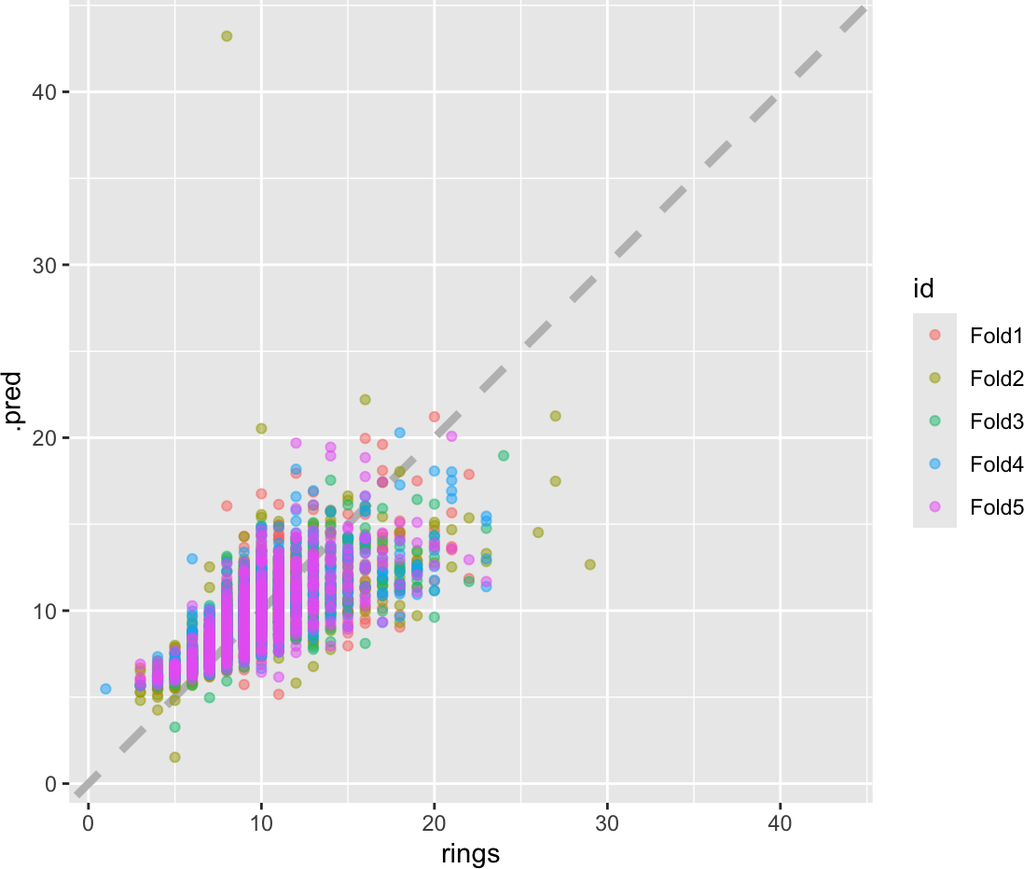

```r
reg_preds %>%
  ggplot(aes(rings, .pred, color = id)) +
  geom_abline(lty = 2, col = "gray", size = 1.5) +
  geom_point(alpha = 0.5) +
  coord_obs_pred()
```

## 7.3 Árvore de decisão

Um outro modelo a ser considerado é árvore de decisão. Vamos considerar o seguinte exemplo:

```r
  tree_spec <- decision_tree(cost_complexity = 0.02) %>%
      set_mode("regression") %>%
      set_engine("rpart")
```

O modelo de árvore de regressão não requer pré-processamento, de forma que podemos usar um workflow com a fórmula e o modelo especificado, por exemplo:

```r
tree_wf <- workflow(rings ~ ., tree_spec)
tree_wf
```

```
## ══ Workflow ════════════════════════════════════════════════════════════════════
## Preprocessor: Formula
## Model: decision_tree()
##
## ── Preprocessor ────────────────────────────────────────────────────────────────
## rings ~ .
##
## ── Model ───────────────────────────────────────────────────────────────────────
## Decision Tree Model Specification (regression)
##
## Main Arguments:
##   cost_complexity = 0.02
##
## Computational engine: rpart
```

E o ajuste é com os dados de treinamento:

```r
tree_fit <- tree_wf %>% fit(data = ring_train)
```

Vamos então avaliar o desempenho da árvore de decisão usando validação cruzada:

```r
tree_cv <- tree_wf %>% fit_resamples(ring_folds)

tree_cv %>% collect_metrics()
```

```
## # A tibble: 2 × 6
##   .metric .estimator  mean     n std_err .config
##   <chr>   <chr>      <dbl> <int>   <dbl> <chr>
## 1 rmse    standard   2.50      5  0.0752 pre0_mod0_post0
## 2 rsq     standard   0.402     5  0.0114 pre0_mod0_post0
```

## 7.4 Conjunto de modelos

Quando queremos comparar vários modelos ao mesmo, fica muito trabalhoso fazer um por vez, como mostramos anteriormente.

Para isso, existe a função `workflow_set()` que gera um conjunto de workflows. Os argumentos desta função são:

- `preproc`: formulas, receitas
- `models`: modelos especificados usando `parsnip`

```r
wf_set <- workflow_set(preproc = list(rec1 = rings ~ ., rec2 = ring_rec),
                       models = list(tree = tree_spec, reg = reg_spec),
                       cross = FALSE)
```

Agora podemos avaliar os modelos com as métricas desejadas usando a validação cruzada:

```r
wf_set %>%
  workflow_map("fit_resamples", resamples = ring_folds) %>%
  rank_results()
```

```
## # A tibble: 4 × 9
##   wflow_id  .config         .metric  mean std_err     n preprocessor model  rank
##   <chr>     <chr>           <chr>   <dbl>   <dbl> <int> <chr>        <chr> <int>
## 1 rec2_reg  pre0_mod0_post0 rmse    2.33   0.126      5 recipe       line…     1
## 2 rec2_reg  pre0_mod0_post0 rsq     0.487  0.0323     5 recipe       line…     1
## 3 rec1_tree pre0_mod0_post0 rmse    2.50   0.0752     5 formula      deci…     2
## 4 rec1_tree pre0_mod0_post0 rsq     0.402  0.0114     5 formula      deci…     2
```

Se o argumento `cross = TRUE` o `workflow_set` faz um produto cruzado das receitas e modelos:

```r
workflow_set(preproc = list(rec1 = rings ~ ., rec2 = ring_rec),
             models = list(tree = tree_spec, reg = reg_spec),
             cross = TRUE) %>%
  workflow_map("fit_resamples", resamples = ring_folds) %>%
  rank_results()
```

```
## # A tibble: 8 × 9
##   wflow_id  .config         .metric  mean std_err     n preprocessor model  rank
##   <chr>     <chr>           <chr>   <dbl>   <dbl> <int> <chr>        <chr> <int>
## 1 rec1_reg  pre0_mod0_post0 rmse    2.24   0.0921     5 formula      line…     1
## 2 rec1_reg  pre0_mod0_post0 rsq     0.521  0.0213     5 formula      line…     1
## 3 rec2_reg  pre0_mod0_post0 rmse    2.33   0.126      5 recipe       line…     2
## 4 rec2_reg  pre0_mod0_post0 rsq     0.487  0.0323     5 recipe       line…     2
## 5 rec1_tree pre0_mod0_post0 rmse    2.50   0.0752     5 formula      deci…     3
## 6 rec1_tree pre0_mod0_post0 rsq     0.402  0.0114     5 formula      deci…     3
## 7 rec2_tree pre0_mod0_post0 rmse    2.50   0.0752     5 recipe       deci…     4
## 8 rec2_tree pre0_mod0_post0 rsq     0.402  0.0114     5 recipe       deci…     4
```

Suponha que o modelo de regressão linear tenha sido o escolhido.

Vamos ajustar o modelo nos dados de treinamento e verificar o desempenho nos dados de teste.

```r
final_fit <- last_fit(reg_wf, ring_split)
```

Lembre-se que o objeto `ring_split` tem informações sobre a separação dos dados originais em treino e teste.

```r
final_fit
```

```
## # Resampling results
## # Manual resampling
## # A tibble: 1 × 6
##   splits             id               .metrics .notes   .predictions .workflow
##   <list>             <chr>            <list>   <list>   <list>       <list>
## 1 <split [3340/837]> train/test split <tibble> <tibble> <tibble>     <workflow>
```

Métricas calculadas para o conjunto de dados **teste**:

```r
collect_metrics(final_fit)
```

```
## # A tibble: 2 × 4
##   .metric .estimator .estimate .config
##   <chr>   <chr>          <dbl> <chr>
## 1 rmse    standard       2.24  pre0_mod0_post0
## 2 rsq     standard       0.505 pre0_mod0_post0
```

Predições para o conjunto de dados **teste**:

```r
collect_predictions(final_fit) %>%
  head()
```

```
## # A tibble: 6 × 5
##   .pred id               rings  .row .config
##   <dbl> <chr>            <dbl> <int> <chr>
## 1  8.14 train/test split     7     2 pre0_mod0_post0
## 2 10.6  train/test split     9     3 pre0_mod0_post0
## 3  6.74 train/test split     7     5 pre0_mod0_post0
## 4 11.2  train/test split    12    16 pre0_mod0_post0
## 5  8.71 train/test split     7    19 pre0_mod0_post0
## 6  8.69 train/test split     9    20 pre0_mod0_post0
```

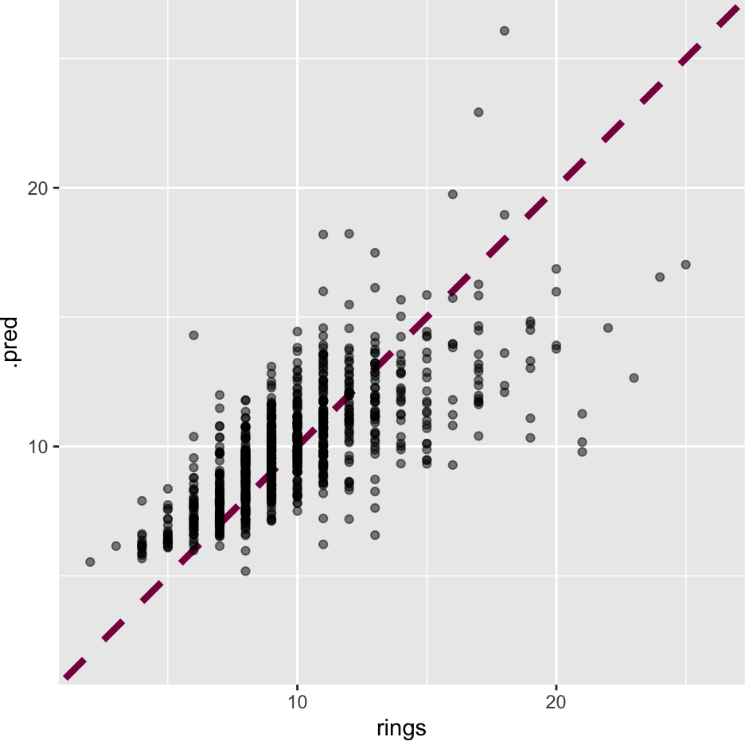

```r
collect_predictions(final_fit) %>%
  ggplot(aes(rings, .pred)) +
  geom_abline(lty = 2, col = "deeppink4", size = 1.5) +
  geom_point(alpha = 0.5) +
  coord_obs_pred()
```

Quais informações temos em `final_fit`?

```r
extract_workflow(final_fit)
```

```
## ══ Workflow [trained] ══════════════════════════════════════════════════════════
## Preprocessor: Recipe
## Model: linear_reg()
##
## ── Preprocessor ────────────────────────────────────────────────────────────────
## 4 Recipe Steps
##
## • step_normalize()
## • step_corr()
## • step_dummy()
## • step_poly()
##
## ── Model ───────────────────────────────────────────────────────────────────────
##
## Call:
## stats::lm(formula = ..y ~ ., data = data)
##
## Coefficients:
##           (Intercept)                 height           shell_weight
##              10.27917                0.59969                3.20871
##            sex_infant               sex_male  shucked_weight_poly_1
##              -1.02274               -0.02678             -127.72989
## shucked_weight_poly_2
##              -7.59663
```

Quais as estimativas dos parâmetros do modelo final?

```r
final_fit %>%
  extract_fit_parsnip() %>%
  tidy()
```

```
## # A tibble: 7 × 5
##   term                   estimate std.error statistic   p.value
##   <chr>                     <dbl>     <dbl>     <dbl>     <dbl>
## 1 (Intercept)             10.3       0.0746   138.    0
## 2 height                   0.600     0.0704     8.52  2.35e- 17
## 3 shell_weight             3.21      0.0953    33.7   2.47e-214
## 4 sex_infant              -1.02      0.118     -8.65  7.83e- 18
## 5 sex_male                -0.0268    0.0964    -0.278 7.81e-  1
## 6 shucked_weight_poly_1 -128.        5.29     -24.2   6.75e-119
## 7 shucked_weight_poly_2   -7.60      2.50      -3.04  2.40e-  3
```

# 8 Hiperparâmetros

Algumas características dos modelos não podem ser estimadas diretamente dos dados.

Escolhemos um modelo de regressão linear, por exemplo, e usamos os dados de treinamento para obter os parâmetros do modelo.

No entanto, algumas escolhas são feitas antes do ajuste do modelo: usaremos alguma forma quadrática? interações? quais variáveis vamos considerar?

Algumas decisões devem ser feitas na etapa *receita* e outras devem ser feitas *dentro do modelo*.

Para ajuste fino, podemos testar *workflows* diferentes e avaliar o desempenho com validação cruzada.

## 8.1 Regressão linear com polinômio

Para um modelo de regressão linear em que uma das variáveis será considerada através de um polinômio, temos a seguinte receita:

```r
ring_rec <-
  recipe(rings ~ ., data = ring_train) %>%
  step_dummy(all_nominal_predictors()) %>%
  step_poly(shucked_weight, degree = tune())
```

Repare que, acima, não especificamos diretamente o grau do polinômio. Vamos escolher o melhor hiperparâmetro usando a função `tune()`.

Com a receita definida, vamos agregar as informações:

```r
regpol_wf <- workflow(ring_rec, linear_reg())
regpol_wf
```

```
## ══ Workflow ════════════════════════════════════════════════════════════════════
## Preprocessor: Recipe
## Model: linear_reg()
##
## ── Preprocessor ────────────────────────────────────────────────────────────────
## 2 Recipe Steps
##
## • step_dummy()
## • step_poly()
##
## ── Model ───────────────────────────────────────────────────────────────────────
## Linear Regression Model Specification (regression)
##
## Computational engine: lm
```

A função `tune_grid()` calcula um conjunto de métricas usando validação cruzada para avaliar o desempenho em um conjunto pré-determinado de hiperparâmetros de um modelo ou de uma receita:

```r
set.seed(123)
regpol_res <- tune_grid(regpol_wf, ring_folds, grid = tibble(degree=1:6))
regpol_res
```

```
## # Tuning results
## # 5-fold cross-validation using stratification
## # A tibble: 5 × 4
##   splits             id    .metrics          .notes
##   <list>             <chr> <list>            <list>
## 1 <split [2670/670]> Fold1 <tibble [12 × 5]> <tibble [0 × 4]>
## 2 <split [2672/668]> Fold2 <tibble [12 × 5]> <tibble [0 × 4]>
## 3 <split [2672/668]> Fold3 <tibble [12 × 5]> <tibble [0 × 4]>
## 4 <split [2673/667]> Fold4 <tibble [12 × 5]> <tibble [0 × 4]>
## 5 <split [2673/667]> Fold5 <tibble [12 × 5]> <tibble [0 × 4]>
```

Apresentando os resultados (média dos 5 *folds*) para cada grau de polinômio (hiperparâmetro) considerado:

```r
collect_metrics(regpol_res)
```

```
## # A tibble: 12 × 7
##    degree .metric .estimator  mean     n std_err .config
##     <int> <chr>   <chr>      <dbl> <int>   <dbl> <chr>
##  1      1 rmse    standard   2.24      5  0.0921 pre1_mod0_post0
##  2      1 rsq     standard   0.521     5  0.0213 pre1_mod0_post0
##  3      2 rmse    standard   2.24      5  0.0952 pre2_mod0_post0
##  4      2 rsq     standard   0.521     5  0.0222 pre2_mod0_post0
##  5      3 rmse    standard   2.22      5  0.0866 pre3_mod0_post0
##  6      3 rsq     standard   0.531     5  0.0191 pre3_mod0_post0
##  7      4 rmse    standard   2.21      5  0.0845 pre4_mod0_post0
##  8      4 rsq     standard   0.535     5  0.0187 pre4_mod0_post0
##  9      5 rmse    standard   2.21      5  0.0813 pre5_mod0_post0
## 10      5 rsq     standard   0.537     5  0.0176 pre5_mod0_post0
## 11      6 rmse    standard   2.21      5  0.0811 pre6_mod0_post0
## 12      6 rsq     standard   0.537     5  0.0176 pre6_mod0_post0
```

Visualização gráfica usando `autoplot()`:

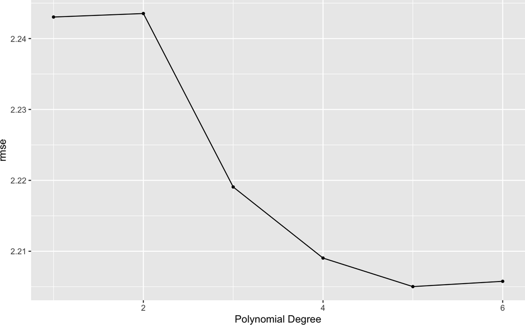

```r
autoplot(regpol_res, metric = "rmse")
```

Mostrando os melhores resultados:

```r
show_best(regpol_res, metric = "rmse", n = 3)
```

```
## # A tibble: 3 × 7
##   degree .metric .estimator  mean     n std_err .config
##    <int> <chr>   <chr>      <dbl> <int>   <dbl> <chr>
## 1      5 rmse    standard    2.21     5  0.0813 pre5_mod0_post0
## 2      6 rmse    standard    2.21     5  0.0811 pre6_mod0_post0
## 3      4 rmse    standard    2.21     5  0.0845 pre4_mod0_post0
```

E se ajustarmos um outro modelo, também com algum outro hiperparâmetro? Como comparar?

## 8.2 Árvore de decisão

A seguir temos um *workflow* para árvore de decisão com ajuste de hiperparâmetro.

Primeiro, o modelo é especificado incluindo `tune()`:

```r
tree_spec <-
  decision_tree(
    cost_complexity = tune()
  ) %>%
  set_mode("regression") %>%
  set_engine("rpart")
```

A receita é definida:

```r
tree_rec <-
  recipe(rings ~ ., data = ring_train) %>%
  step_dummy(all_nominal_predictors())
```

Essas duas informações são agregadaas com *workflow*:

```r
tree_wf <- workflow(tree_rec, tree_spec)
```

Vamos usar `tune_grid()` para avaliar vários valores para o hiperparâmwtro:

```r
set.seed(9)
tree_res <-
  tune_grid(tree_wf,
            resamples = ring_folds,
            grid = 15,
            metrics = abalone_metrics)
```

É possível fornecer um `data.frame` na opção `grid`, para ser mais específico.

Métricas obtidas através de validação cruzada considerando os valores de `grid`:

```r
tree_res %>% collect_metrics()
```

```
## # A tibble: 60 × 7
##    cost_complexity .metric .estimator   mean     n std_err .config
##              <dbl> <chr>   <chr>       <dbl> <int>   <dbl> <chr>
##  1        1.13e-10 mae     standard    1.73      5  0.0492 pre0_mod01_post0
##  2        1.13e-10 mape    standard   17.0       5  0.426  pre0_mod01_post0
##  3        1.13e-10 rmse    standard    2.43      5  0.0858 pre0_mod01_post0
##  4        1.13e-10 rsq     standard    0.462     5  0.0160 pre0_mod01_post0
##  5        5.76e-10 mae     standard    1.73      5  0.0492 pre0_mod02_post0
##  6        5.76e-10 mape    standard   17.0       5  0.426  pre0_mod02_post0
##  7        5.76e-10 rmse    standard    2.43      5  0.0858 pre0_mod02_post0
##  8        5.76e-10 rsq     standard    0.462     5  0.0160 pre0_mod02_post0
##  9        2.23e- 9 mae     standard    1.73      5  0.0492 pre0_mod03_post0
## 10        2.23e- 9 mape    standard   17.0       5  0.426  pre0_mod03_post0
## # ℹ 50 more rows
```

Em resumo, o melhor resultado para regressão polinomial, segundo a validação cruzada:

```r
regpol_res %>%
  show_best(metric = "rmse", n = 1) %>%
  select(.metric, .estimator, mean, n, std_err, .config)
```

```
## # A tibble: 1 × 6
##   .metric .estimator  mean     n std_err .config
##   <chr>   <chr>      <dbl> <int>   <dbl> <chr>
## 1 rmse    standard    2.21     5  0.0813 pre5_mod0_post0
```

```r
tree_res %>%
  show_best(metric = "rmse", n = 1) %>%
  select(.metric, .estimator, mean, n, std_err, .config)
```

```
## # A tibble: 1 × 6
##   .metric .estimator  mean     n std_err .config
##   <chr>   <chr>      <dbl> <int>   <dbl> <chr>
## 1 rmse    standard    2.34     5  0.0851 pre0_mod13_post0
```

Entre as duas opções (regressão polinomial e árvore), vamos ficar com a regressão polinomial. Vamos selecionar o modelo com hiperparâmtro de melhor desempenho:

```r
best_rmse <- select_best(regpol_res, metric = "rmse")
best_rmse
```

```
## # A tibble: 1 × 2
##   degree .config
##    <int> <chr>
## 1      5 pre5_mod0_post0
```

E ajustando o modelo final:

```r
final_res <-
  regpol_wf %>%
  finalize_workflow(best_rmse) %>%
  last_fit(ring_split)
final_res
```

```
## # Resampling results
## # Manual resampling
## # A tibble: 1 × 6
##   splits             id               .metrics .notes   .predictions .workflow
##   <list>             <chr>            <list>   <list>   <list>       <list>
## 1 <split [3340/837]> train/test split <tibble> <tibble> <tibble>     <workflow>
```

`last_fit()` ajusta o modelo final com os dados de treino e avalia o desempenho nos dados de teste.

Resultado no conjunto de teste:

```r
final_res %>% collect_metrics()
```

```
## # A tibble: 2 × 4
##   .metric .estimator .estimate .config
##   <chr>   <chr>          <dbl> <chr>
## 1 rmse    standard       2.18  pre0_mod0_post0
## 2 rsq     standard       0.533 pre0_mod0_post0
```

*Workflow* final

Guardar todos os passos do ajuste final (obtidos usando o conjunto de treinamento):

```r
fitted_wf <- extract_workflow(final_res)
fitted_wf
```

```
## ══ Workflow [trained] ══════════════════════════════════════════════════════════
## Preprocessor: Recipe
## Model: linear_reg()
##
## ── Preprocessor ────────────────────────────────────────────────────────────────
## 2 Recipe Steps
##
## • step_dummy()
## • step_poly()
##
## ── Model ───────────────────────────────────────────────────────────────────────
##
## Call:
## stats::lm(formula = ..y ~ ., data = data)
##
## Coefficients:
##           (Intercept)                 length               diameter
##              -0.05048               -6.66421                9.96106
##                height           whole_weight         viscera_weight
##               7.33184                9.41184               -8.93447
##          shell_weight             sex_infant               sex_male
##              10.52625               -0.96181               -0.01411
## shucked_weight_poly_1  shucked_weight_poly_2  shucked_weight_poly_3
##            -241.15746               -8.36663               24.57516
## shucked_weight_poly_4  shucked_weight_poly_5
##             -11.06719                8.32636
```

Obter valores preditos:

```r
predict(fitted_wf, ring_test[1:3,])
```

```
## # A tibble: 3 × 1
##   .pred
##   <dbl>
## 1  8.06
## 2 11.4
## 3  6.85
```

*Workflow* final:

```r
final_res %>%
  extract_fit_parsnip() %>%
  tidy()
```

```
## # A tibble: 14 × 5
##    term                   estimate std.error statistic  p.value
##    <chr>                     <dbl>     <dbl>     <dbl>    <dbl>
##  1 (Intercept)             -0.0505    0.740    -0.0682 9.46e- 1
##  2 length                  -6.66      2.23     -2.99   2.79e- 3
##  3 diameter                 9.96      2.59      3.84   1.24e- 4
##  4 height                   7.33      1.64      4.47   8.14e- 6
##  5 whole_weight             9.41      0.790    11.9    4.84e-32
##  6 viscera_weight          -8.93      1.42     -6.29   3.57e-10
##  7 shell_weight            10.5       1.25      8.44   4.57e-17
##  8 sex_infant              -0.962     0.115    -8.38   7.49e-17
##  9 sex_male                -0.0141    0.0926   -0.152  8.79e- 1
## 10 shucked_weight_poly_1 -241.       12.1     -19.9    3.33e-83
## 11 shucked_weight_poly_2   -8.37      3.79     -2.21   2.73e- 2
## 12 shucked_weight_poly_3   24.6       2.71      9.07   1.96e-19
## 13 shucked_weight_poly_4  -11.1       2.34     -4.73   2.34e- 6
## 14 shucked_weight_poly_5    8.33      2.25      3.70   2.23e- 4
```

# Referências

Hastie, Trevor, Robert Tibshirani, and Jerome Friedman. 2001. *The Elements of Statistical Learning*. Springer Series in Statistics. Springer New York Inc.

James, Gareth, Daniela Witten, Trevor Hastie, and Robert Tibshirani. 2013. *An Introduction to Statistical Learning: With Applications in r*. Springer. https://www.statlearning.com.

Kuhn, M., and J. Silge. 2022. *Tidy Modeling with r*. O’Reilly Media. https://www.tmwr.org.

Nash, Sellers, Warwick, and Wes Ford. 1995. *Abalone*. UCI Machine Learning Repository.